# Botswana Covid-19 Analysis

First we start with some of the tools we are going to use for the analysis as well as the datasets

### Importing datasets

```python
#importing of the modules I will use for the report

from pandas import Series, DataFrame
import pandas as pd
import numpy as np
import pycountry_convert as pc
import matplotlib.pyplot as plt
from datetime import datetime, timedelta,date
import plotly as px
from IPython.core.display import display, HTML
from cycler import cycler
import seaborn as sns
sns.set(style="whitegrid")
```

```python
#RETREIVING DATASETS

confirmed_df = pd.read_csv('C:/Users/y4...4#1#1/Desktop/Data Science Study/Exercises\/COVID-19 Botswana/covid-19/time_series_covid19_confirmed_global.csv')
deaths_df = pd.read_csv('C:/Users/y4...4#1#1/Desktop/Data Science Study/Exercises\/COVID-19 Botswana/covid-19/time_series_covid19_deaths_global.csv')
recovered_df = pd.read_csv('C:/Users/y4...4#1#1/Desktop/Data Science Study/Exercises\/COVID-19 Botswana/covid-19/time_series_covid19_recovered_global.csv')
cases_df = pd.read_csv('C:/Users/y4...4#1#1/Desktop/Data Science Study/Exercises\/COVID-19 Botswana/covid-19/cases_country.csv')

bots_confirmed = pd.read_csv('C:/Users/y4...4#1#1/Desktop/Data Science Study/Exercises\/COVID-19 Botswana/covid-19/COVID-19-Botswana.csv')


# Total number of confirmed, death and recovered cases
confirmed_total = int(cases_df['Confirmed'].sum())
deaths_total = int(cases_df['Deaths'].sum())
recovered_total = int(cases_df['Recovered'].sum())
active_total = int(cases_df['Active'].sum())
```

# Tracking Covid-19 in Botswana ver 1.0.1

## Analysis, Visualization, Comparison between trends with other countries as well as attempting to predict what is next in terms of the pandemic

### Introduction to Covid-19

Corona Virus now known as Covid-19 is a new form of virus that can cause the body to have severe problems such as Severe Acute Respiratory Syndrome (SARS-CoV) which most peole know as the common flu and coughing etc.

We now have a new form of SAR-Cov-2 of this Corona Virus which most scientists discovered sometimes mid 2019. It is a very contagious disease as it easily spread from contacts with persons infected, or anything that an infected had contact with.

As we all know from the news the disease broke around December 2019 in Wuhan, China before spreading across the whole world, ultimately as we are now aware affecting us in Botswana too. Currently as it is WHO has declared a pandemic because of it lethal nature we witnessing across the world.

As it is now, the pandemic is devastating the whole world: COUNTER BELOW illustrates the current figures as they stand

```python
# Displaying the total stats

display(HTML("<div style = 'background-color:Transparent; padding: 30px '>" +
             "<span style='padding:20px; color: #D3D3D3; font-size:20px;margin-left:0px float:left; border: 1px solid #e0e0e0;box-shadow: 0 3px 6px 1px rgba(0, 0, 0, 0.16); '> CONFIRMED CASES "  + str(confirmed_total) +"</span>" +
             "<span style='padding:20px; color: #D3D3D3; font-size:20px;margin-left:5px; border: 1px solid #e0e0e0;box-shadow: 0 3px 6px 1px rgba(0, 0, 0, 0.16);'> GLOBAL DEATHS " + str(deaths_total) + "</span>"+
             "<span style='padding:20px; color: #D3D3D3; font-size:20px; margin-left:5px; border: 1px solid #e0e0e0;box-shadow: 0 3px 6px 1px rgba(0, 0, 0, 0.16);'> RECOVERED CASES " + str(recovered_total) + "</span>"+
             "</div>")
       )
```

CONFIRMED CASES 1484811 GLOBAL DEATHS 88538 RECOVERED CASES 329876

As Covid-19 ravages the world and our beloved Botswana it becomes paramount to understand this spread. I will analyze cumulative data of confirmed, death ans well as other data I collect and keep on growing the dataset that I am building from various data sources around the world.

- With the world data it is not much of a problem as that is easily available around the internet as opensource datasets
- What is proving to be a challenge is Botswana data, I have for past week been doing what we call as data munging or wrangling to gather data with regards to tthe pandemic. Mostly in Botswana my sources are from news outlets and official Facebook pages.

Further I will develop a model to predict the infection rate of Botswana over time.

NB: Please refer to the end of the report to see some of the references given to some of these sources.

# Table of Contents :

Introduction to Covid-19

1. Importing datasets
- Pre Processing
- Functions Definitions
- Quick Analysis of Botswana
  - Botswana
  - Botswana vs World
  - Working on local data
  - **Analysis of tests done in Botswana vs South-Africa**
- COVID-19 Spread Analysis
  - Spread Analysis Botswana
  - COVID-19 Spread Comparison with the world
- Correlation Analysis
- **Visualization on Map**
  - Global Confirmed Cases Heat Map
  - Global Deaths Heat Map
  - **COVID-19: Spread Progression**
- Botswana Prediction
  - **Tabulation of prediction and actual figures that may be after 30th April**
- COVID-19 Mortality Rate Variation Over Period of Time
  - COVID-19: Change in Mortality Rate of Each Countries Over Time
- Comparision of Mortality and Recovery Rate
  - Variation of Deaths vs Confirmed cases of different cuntries over time
    - **To be updated as we get recoveries in Botswana. Currently we are at zero**
- Valuable Feedback is Welcome
- References

**You can also follow my work on github [Version 1.0.1](https://www.kaggle.com/tarunkr/covid-19-case-study-analysis-viz-comparisons?scriptVersionId=30677812) of this notebook**.

# Pre Processing

### Data Cleaning

```python
#dropping some column names and renaming them

confirmed_df = confirmed_df.rename(columns={"Province/State":"State","Country/Region": "Country"})
deaths_df = deaths_df.rename(columns={"Province/State":"State","Country/Region": "Country"})
cases_df = cases_df.rename(columns={"Country_Region": "Country"})
cases_df["Active"] = cases_df["Confirmed"]-cases_df["Recovered"]-cases_df["Deaths"]

bots_confirmed = bots_confirmed.rename(columns = {"Suspected;Cases":"Suspected Cases", "Tested;Positive":"Tested Positive", "Tested;Negative":"Tested Negative", "Pending":"Pending","Testing;per;;%;of;population":"% Testing Ratio","Increase;since;last;Last;Death": "Days since last death", "Increase;since;last;Confirmed": "Days since last case", "Death":"Death", "Source":"Source"})
```

Checking if the cleaning and renaming of the cloumns was successful

```python
confirmed_df.head(3)
```

|  | State | Country | Lat | Long | 1/22/20 | 1/23/20 | 1/24/20 | 1/25/20 | 1/26/20 | 1/27/20 | ... | 3/30/20 | 3/31/20 | 4/1/20 | 4/2/20 | 4/3/20 | 4/4/20 | 4/5/20 | 4/6/20 | 4/7/20 | 4/8/20 |
| --- | --- | --- | --- | --- | --- | --- | --- | --- | --- | --- | --- | --- | --- | --- | --- | --- | --- | --- | --- | --- | --- |
| 0 | NaN | Afghanistan | 33.0000 | 65.0000 | 0 | 0 | 0 | 0 | 0 | 0 | ... | 170 | 174 | 237 | 273 | 281 | 299 | 349 | 367 | 423 | 444 |
| 1 | NaN | Albania | 41.1533 | 20.1683 | 0 | 0 | 0 | 0 | 0 | 0 | ... | 223 | 243 | 259 | 277 | 304 | 333 | 361 | 377 | 383 | 400 |
| 2 | NaN | Algeria | 28.0339 | 1.6596 | 0 | 0 | 0 | 0 | 0 | 0 | ... | 584 | 716 | 847 | 986 | 1171 | 1251 | 1320 | 1423 | 1468 | 1572 |

3 rows × 82 columns

```python
bots_confirmed.head(5)
```

|  | Date | Quarantined | Suspected Cases | Tested Positive | Tested Negative | Pending | Deaths | Unnamed: 7 | % Testing Ratio | Days since last death | Days since last case | Source |
| --- | --- | --- | --- | --- | --- | --- | --- | --- | --- | --- | --- | --- |
| 0 | 26/03/2020 | 0.0 | 0.0 | 0.0 | 0.0 | 0.0 | 0.0 | NaN | NaN | 0.0 | NaN | ;;;;;;;;;;;;;;; |
| 1 | 27/03/2020 | 0.0 | 0.0 | 0.0 | 0.0 | 0.0 | 0.0 | NaN | NaN | 0.0 | NaN | ;;;;;;;;;;;;;;; |
| 2 | 28/03/2020 | 1753.0 | 259.0 | 0.0 | 90.0 | 169.0 | 0.0 | NaN | NaN | 0.0 | NaN | ;;;;;;;;;;;;;;; |
| 3 | 29/03/2020 | NaN | 93.0 | 3.0 | 90.0 | NaN | 0.0 | NaN | NaN | 0.0 | NaN | ;;;;;;;;;;;;;;; |
| 4 | 30/03/2020 | NaN | NaN | 3.0 | 0.0 | NaN | 0.0 | NaN | NaN | 0.0 | NaN | www.africanews.com/statistics/2020/01/04botswa... |

```python
cases_df.head(2)
```

|  | Country | Last_Update | Lat | Long_ | Confirmed | Deaths | Recovered | Active |
| --- | --- | --- | --- | --- | --- | --- | --- | --- |
| 0 | Australia | 2020-04-09 02:33:55 | -25.0000 | 133.0000 | 6010 | 50 | 1080 | 4880 |
| 1 | Austria | 2020-04-09 02:26:07 | 47.5162 | 14.5501 | 12942 | 273 | 4512 | 8157 |

Everything looks fine, the columns I changed names on the dataframes have indeed been changed.I will start working with the dataframes. So I will move onto defining some functions I am going to use for the analysis of the data.

### Functions Definitions

I will also assign many variables values also here

```python
#country cases with Mortality Rates
country_cases_mort_df = cases_df.copy().drop(['Lat','Long_','Last_Update'],axis =1)
country_cases_mort_df = country_cases_df.groupby(["Country"]).sum()
country_cases_mort_df["Mortality Rate (per 100)"] = np.round(100*country_cases_mort_df["Deaths"]/country_cases_mort_df["Confirmed"],2)

#Southern African country cases
countries_Southern_Africa = DataFrame(country_cases_df, columns=['Confirmed', 'Deaths', 'Recorvered', 'Active'],index=['Botswana', 'South Africa', 'Zimbabwe', 'Namibia', 'Zambia'])

#Southern African country cases with Mortality Rates
countries_Southern_Africa_mortality = DataFrame(country_cases_mort_df, columns=['Confirmed', 'Deaths', 'Recorvered', 'Active','Mortality Rate (per 100)'],index=['Botswana', 'South Africa', 'Zimbabwe', 'Namibia', 'Zambia'])


#Plotting pie chart for Southern African country cases with Mortality Rates
countries_SA_mort = pd.DataFrame({'Mortality Rates': [16.67, 0.98, 27.27 , 0, 2.56]},
                  index=['Botswana', 'South Africa', 'Zimbabwe', 'Namibia', 'Zambia'])

#World cases with Mortality Rates
countries_world_mortality = DataFrame(country_cases_mort_df, columns=['Confirmed', 'Deaths', 'Recorvered', 'Active','Mortality Rate (per 100)'],index=['US', 'China', 'Italy', 'Spain', 'United Kingdom','Botswana'])

#Plotting pie chart for World country cases with Mortality Rates
countries_world_mort = pd.DataFrame({'Mortality Rates': [3.43, 4.03, 12.67 , 9.98, 11.57, 16.67]},
                  index=['US', 'China', 'Italy', 'Spain', 'United Kingdom','Botswana'])


#defining dates and converting to datetime from string (will later create function to convert)

str_28 = datetime(2020,3,28,0,0)
str_29 = datetime(2020,3,29,0,0)
str_1 = datetime(2020,4,1,0,0)
str_2 = datetime(2020,4,2,0,0)
str_4 = datetime(2020,4,4,0,0)
str_5 = datetime(2020,4,5,0,0)
str_6 = datetime(2020,4,6,0,0)
str_9 = datetime(2020,4,9,0,0)
datetime_string_format = '%b %d %Y, %H:%M:%S'

da_28 = datetime.strftime(str_28,datetime_string_format)
da_29 = datetime.strftime(str_29,datetime_string_format)
da_1 = datetime.strftime(str_1,datetime_string_format)
da_2 = datetime.strftime(str_2,datetime_string_format)
da_4 = datetime.strftime(str_4,datetime_string_format)
da_5 = datetime.strftime(str_5,datetime_string_format)
da_6 = datetime.strftime(str_6,datetime_string_format)
da_9 = datetime.strftime(str_9,datetime_string_format)
#datetime.strftime(str_28,datetime_string_format)
```

## Quick Analysis of Botswana

### Botswana

Latest confirmed, death & recovered cases on Botswana as per datasets

- time_series_covid19_confirmed_global.csv
- time_series_covid19_deaths_global.csv

  I will also work on the dataset I am currently working on.
- Self developed datasets from various news outlets Botswana

```python
#Confirmed cases in Botswana

confirmed_Botswana = cases_df[cases_df['Country'] == "Botswana"]
confirmed_Botswana = confirmed_Botswana.drop(['Lat', 'Long_', 'Country', 'Last_Update'], axis = 1)
Botswana_Summary = pd.DataFrame(confirmed_Botswana.sum()).transpose()
Botswana_Summary.style.format("{:,.0f}")
```

|  | Confirmed | Deaths | Recovered | Active |
| --- | --- | --- | --- | --- |
| 0 | 6 | 1 | 0 | 5 |

```python
#Computation of mortality rate for Botswana

confirmed_Botswana = cases_df[cases_df['Country'] == "Botswana"]
confirmed_Botswana = confirmed_Botswana.drop(['Lat', 'Long_', 'Country', 'Last_Update'], axis = 1)
Botswana_Summary = pd.DataFrame(confirmed_Botswana.sum()).transpose()
Botswana_Summary["Mortality Rate (per 100)"] = np.round(100*Botswana_Summary["Deaths"]/Botswana_Summary["Confirmed"],2)
Botswana_Summary.style.background_gradient(axis=1).format("{:.0f}",subset=["Confirmed"])
#Botswana_Summary.style.format("{:,.0f}")
```

|  | Confirmed | Deaths | Recovered | Active | Mortality Rate (per 100) |
| --- | --- | --- | --- | --- | --- |
| 0 | 6 | 1 | 0 | 5 | 16.670000 |

Whilst at it we have to keep an eye on our biggest neighbour South Africa as well as our neighbours. This will will give us an idea of where our region stand and help in decision making by our leaders such as opening of borders. I have decided to include South Africa as everything that happens there affects our small country.

### South Africa

```python
#Confirmed cases in South Africa

confirmed_SouthAfrica = cases_df[cases_df['Country'] == "South Africa"]
confirmed_SouthAfrica = confirmed_SouthAfrica.drop(['Lat', 'Long_', 'Country', 'Last_Update'], axis = 1)
SA_Summary = pd.DataFrame(confirmed_SouthAfrica.sum()).transpose()
SA_Summary.style.format("{:,.0f}")
```

|  | Confirmed | Deaths | Recovered | Active |
| --- | --- | --- | --- | --- |
| 0 | 1,845 | 18 | 95 | 1,732 |

```python
#Computation of maortality rate for South Africa

confirmed_SouthAfrica = cases_df[cases_df['Country'] == "South Africa"]
confirmed_SouthAfrica = confirmed_SouthAfrica.drop(['Lat', 'Long_', 'Country', 'Last_Update'], axis = 1)
SA_Summary = pd.DataFrame(confirmed_SouthAfrica.sum()).transpose()
SA_Summary["Mortality Rate (per 100)"] = np.round(100*SA_Summary["Deaths"]/SA_Summary["Confirmed"],2)
SA_Summary.style.background_gradient(axis=1).format("{:.0f}",subset=["Confirmed"])
```

|  | Confirmed | Deaths | Recovered | Active | Mortality Rate (per 100) |
| --- | --- | --- | --- | --- | --- |
| 0 | 1845 | 18 | 95 | 1732 | 0.980000 |

As seen above, the numbers clearly shows Botswana has a higher mortality rate then South Africa. This is so because of the relation between the confirmed cases and death figures.

And now for the world the figures are as follows

```python
#Computation of maortality rate for World

global_data = cases_df.copy().drop(['Lat', 'Long_', 'Country', 'Last_Update'], axis = 1)
global_summary = pd.DataFrame(global_data.sum()).transpose()
global_summary
```

|  | Confirmed | Deaths | Recovered | Active |
| --- | --- | --- | --- | --- |
| 0 | 1484811 | 88538 | 329876 | 1066397 |

```python
#computation of maortality rate for world

global_data = cases_df.copy().drop(['Lat', 'Long_', 'Country', 'Last_Update'], axis = 1)
global_summary = pd.DataFrame(global_data.sum()).transpose()
global_summary["Mortality Rate (per 100)"] = np.round(100*global_summary["Deaths"]/global_summary["Confirmed"],2)
global_summary.style.background_gradient(axis=1).format("{:.0f}",subset=["Confirmed"])
```

|  | Confirmed | Deaths | Recovered | Active | Mortality Rate (per 100) |
| --- | --- | --- | --- | --- | --- |
| 0 | 1484811 | 88538 | 329876 | 1066397 | 5.960000 |

As seen above clearly the death rate in comparison to South Africa and the rest of the World is very high.. This clearly shows that we are in danger and should be more careful. it gives weight to the request by government message to it citizens to stay home. I will as below do a thorough comparison and analysis of this fact.

Below I will look at cases for all countries in Africa to get a better picture of severity of disease in; before comparing the moratality rate for interconnected Southern Africa neighbours South Africa , Zimbabwe, Namibia and Zambia

### Botswana vs World

```python
#Confirmed cases in the world

country_cases_df = cases_df.copy().drop(['Lat','Long_','Last_Update'],axis =1)
country_cases_df = country_cases_df.groupby(["Country"]).sum()
country_cases_df
```

| Country | Confirmed | Deaths | Recovered | Active |
| --- | --- | --- | --- | --- |
| Afghanistan | 444 | 14 | 29 | 401 |
| Albania | 400 | 22 | 154 | 224 |
| Algeria | 1572 | 205 | 237 | 1130 |
| Andorra | 564 | 23 | 52 | 489 |
| Angola | 19 | 2 | 2 | 15 |
| ... | ... | ... | ... | ... |
| Vietnam | 251 | 0 | 126 | 125 |
| West Bank and Gaza | 263 | 1 | 44 | 218 |
| Western Sahara | 4 | 0 | 0 | 4 |
| Zambia | 39 | 1 | 7 | 31 |
| Zimbabwe | 11 | 3 | 0 | 8 |

184 rows × 4 columns

Country Cases with Mortality Rates

```python
country_cases_mort_df
```

[output not shown]

184 rows × 5 columns

Now let us now compare the Southern African countries cases

```python
countries_Southern_Africa
```

|  | Confirmed | Deaths | Recorvered | Active |
| --- | --- | --- | --- | --- |
| Botswana | 6 | 1 | NaN | 5 |
| South Africa | 1845 | 18 | NaN | 1732 |
| Zimbabwe | 11 | 3 | NaN | 8 |
| Namibia | 16 | 0 | NaN | 13 |
| Zambia | 39 | 1 | NaN | 31 |

Next let us now compare the Southern African countries' mortality rates

```python
countries_Southern_Africa_mortality.style.background_gradient(axis=1).format("{:.0f}",subset=["Confirmed"])
```

|  | Confirmed | Deaths | Recorvered | Active | Mortality Rate (per 100) |
| --- | --- | --- | --- | --- | --- |
| Botswana | 6 | 1 | nan | 5 | 16.670000 |
| South Africa | 1845 | 18 | nan | 1732 | 0.980000 |
| Zimbabwe | 11 | 3 | nan | 8 | 27.270000 |
| Namibia | 16 | 0 | nan | 13 | 0.000000 |
| Zambia | 39 | 1 | nan | 31 | 2.560000 |

NB: Please note the mortality rate is basically the death rate in simple terms.

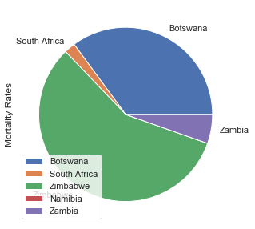

```python
plot = countries_SA_mort.plot.pie(y='Mortality Rates', figsize=(5, 5))
```

Notwithstanding that if you take a look at the figures in terms of confirmed cases, South Africa would lead, in Southern Africa. This shows that more people in our neighbouring country are getting the virus compared to us(Botswana); but because of population size in relation; their mortality rate is lower. Though in actual fact more people would have died that side.

### Confirmed Cases Comparison between Botswana & it neighbours

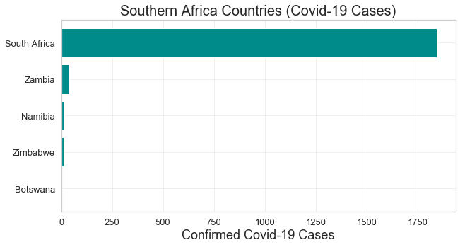

```python
#Plotting Confirmed Cases Comparison between Botswana & it neighbours
confirmed_cases = plt.figure(figsize=(10,5))
confirmed_cases.add_subplot(111)

plt.axes(axisbelow=True)
plt.barh(countries_Southern_Africa.sort_values('Confirmed')["Confirmed"].index[-10:],countries_Southern_Africa.sort_values('Confirmed')["Confirmed"].values[-10:],color="darkcyan")
plt.tick_params(size=5,labelsize = 13)
plt.xlabel("Confirmed Covid-19 Cases",fontsize=18)
plt.title("Southern Africa Countries (Covid-19 Cases)",fontsize=20)

plt.grid(alpha=0.3)
```

### Death Cases Comparison between Botswana & it neighbours

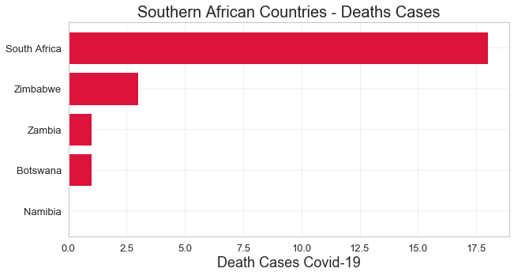

```python
#Plotting Death Cases Comparison between Botswana & it neighbours
confirmed_deaths = plt.figure(figsize=(10,5))
confirmed_deaths.add_subplot(111)

plt.axes(axisbelow=True)
plt.barh(countries_Southern_Africa.sort_values('Deaths')["Deaths"].index[-10:],countries_Southern_Africa.sort_values('Deaths')["Deaths"].values[-10:],color="crimson")
plt.tick_params(size=5,labelsize = 13)
plt.xlabel("Death Cases Covid-19",fontsize=18)
plt.title("Southern African Countries - Deaths Cases",fontsize=20)
plt.grid(alpha=0.3,which='both')
```

That simply means the rate at which people die in relation to confirmed cases is higher in Botswana. This rate if one take it and comapre it to the rest of the world is still relatively high.

For illustration purposes of this fact I will plot our mortality rate amongst some of the hardest hit nations in the world.

```python
countries_world_mortality .style.background_gradient(axis=1).format("{:.0f}",subset=["Confirmed"])
```

|  | Confirmed | Deaths | Recorvered | Active | Mortality Rate (per 100) |
| --- | --- | --- | --- | --- | --- |
| US | 432132 | 14817 | nan | 393409 | 3.430000 |
| China | 82867 | 3339 | nan | 1889 | 4.030000 |
| Italy | 139422 | 17669 | nan | 95262 | 12.670000 |
| Spain | 148220 | 14792 | nan | 85407 | 9.980000 |
| United Kingdom | 61474 | 7111 | nan | 54018 | 11.570000 |
| Botswana | 6 | 1 | nan | 5 | 16.670000 |

The graph above further illustrates my point that we in Botswana have to be careful on how we deal with this epidemic and put in strenous measures in place to mitigate. This is emphasized by fact that already we have a high mortality rates compared to some of the hardest hit countries in the world.

An illustration of the above as a pie chart..

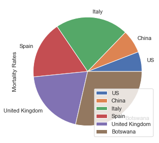

```python
plot = countries_world_mort.plot.pie(y='Mortality Rates', figsize=(5, 5))
```

This clearly is evident that should the disease/virus follow the same trends as the most developed nations we could reach catastrophic troubles here as we are no match to them in terms of facilities such as health specialists, equipment etc. So it is clear for me; Botswana has no option but to stay home.. It also indicates that the country leadership could be spot on on the 6 months monitoring and managing this situation.

To further get the facts to support such an idea I will start by looking at the Covid-19 trends in some of these hard hit countries in relation to Botswana and South Africa:

### Working on local data

This data as mentioned above is developend by munging from various sources, and mostly where possible from Government Facebook Page

I will start by loading the datasets into dataframes and testing below to check if everything is ok.

```python
bots_confirmed.head(16)
```

|  | Date | Quarantined | Suspected Cases | Tested Positive | Tested Negative | Pending | Deaths | Unnamed: 7 | % Testing Ratio | Days since last death | Days since last case | Source |
| --- | --- | --- | --- | --- | --- | --- | --- | --- | --- | --- | --- | --- |
| 0 | 26/03/2020 | 0.0 | 0.0 | 0.0 | 0.0 | 0.0 | 0.0 | NaN | NaN | 0.0 | NaN | ;;;;;;;;;;;;;;; |
| 1 | 27/03/2020 | 0.0 | 0.0 | 0.0 | 0.0 | 0.0 | 0.0 | NaN | NaN | 0.0 | NaN | ;;;;;;;;;;;;;;; |
| 2 | 28/03/2020 | 1753.0 | 259.0 | 0.0 | 90.0 | 169.0 | 0.0 | NaN | NaN | 0.0 | NaN | ;;;;;;;;;;;;;;; |
| 3 | 29/03/2020 | NaN | 93.0 | 3.0 | 90.0 | NaN | 0.0 | NaN | NaN | 0.0 | NaN | ;;;;;;;;;;;;;;; |
| 4 | 30/03/2020 | NaN | NaN | 3.0 | 0.0 | NaN | 0.0 | NaN | NaN | 0.0 | NaN | www.africanews.com/statistics/2020/01/04botswa... |
| 5 | 31/03/2020 | NaN | NaN | NaN | NaN | NaN | 0.0 | NaN | NaN | 0.0 | NaN | BwGovernment;;;;;;;;;;;;;;; |
| 6 | 01/04/20 | 1856.0 | 593.0 | 4.0 | 189.0 | 404.0 | 1.0 | NaN | NaN | 0.0 | NaN | ;;;;;;;;;;;;;;; |
| 7 | 02/04/20 | NaN | 670.0 | 4.0 | 562.0 | 96.0 | 1.0 | NaN | NaN | 1.0 | 1.0 | DumaFm;FB;page;;;;;;;;;;;;; |
| 8 | 03/04/20 | NaN | NaN | NaN | NaN | NaN | 1.0 | NaN | NaN | 0.0 | 0.0 | ;;;;;;;;;;;;;;; |
| 9 | 04/04/20 | NaN | 820.0 | 4.0 | 656.0 | 164.0 | 1.0 | NaN | NaN | 0.0 | 0.0 | BwGovernment;;;;;;;;;;;;;;; |
| 10 | 05/04/20 | 2065.0 | 966.0 | 6.0 | 804.0 | 156.0 | 1.0 | NaN | NaN | 0.0 | 0.0 | BwGovernment;;;;;;;;;;;;;;; |
| 11 | 06/04/20 | NaN | 1154.0 | 6.0 | 1148.0 | NaN | 1.0 | NaN | NaN | 0.0 | 2.0 | DumaFm;page;;;;;;;;;;;;;; |
| 12 | 07/04/20 | NaN | NaN | NaN | NaN | NaN | 1.0 | NaN | NaN | 0.0 | 0.0 | ;;;;;;;;;;;;;;; |
| 13 | 08/04/20 | NaN | NaN | NaN | NaN | NaN | 1.0 | NaN | NaN | 0.0 | 0.0 | ;;;;;;;;;;;;;;; |
| 14 | 09/04/20 | NaN | 2527.0 | 13.0 | 2514.0 | NaN | 1.0 | NaN | NaN | 0.0 | 7.0 | Mmegi;;;;;;;;;;;;;;; |
| 15 | 10/04/20 | NaN | NaN | NaN | NaN | NaN | NaN | NaN | NaN | NaN | NaN | ;;;;;;;;;;;;;;; |

```python
bots_confirmed.columns
```

```
Index(['Date', 'Quarantined', 'Suspected Cases', 'Tested Positive',
       'Tested Negative', 'Pending', 'Deaths', 'Unnamed: 7', '% Testing Ratio',
       'Days since last death', 'Days since last case', 'Source'],
      dtype='object')
```

Everything looks fine and I have cleaned the data. I can now analyze the data I collected locally.

Please note that the NaN stands for Not a Number which is what pandas uses as a stand in value for missing data. Wherever there is the NaN ; data is missing If you going through this notebook and can contribute to completing the data you would most welcome. Data collection in Botswana is a tedious and not straight forward job though generally data collection and preparation is tricky the world over.

NOTE: Now that the data is incosistent and have so many gaps, I am planning on retrieving the available data from the dataset into my own dataFrame before I can work with it in my analysis, in what is known as data wrangling.

```python
data = {'columns': ['Suspected Cases', 'Tested Positive', 'Tested Negative','Pending','Death','% Testing Ratio'],
       '28/03/2020':[259,0,90,169,0,0],
       '29/03/2020':[259,3,90,166,0,0],
       '01/04/2020':[593,4,189,404,1,0],
       '02/04/2020':[670,4,562,96,1,0],
       '04/04/2020':[820,4,656,164,1,0],
       '05/04/2020':[966,6,804,156,1,0],
       '06/04/2020':[1154,6,1148,0,1,0],
       '09/04/2020':[2527,13,2514,0,1,0],}
cases = DataFrame(data)
cases
```

|  | columns | 28/03/2020 | 29/03/2020 | 01/04/2020 | 02/04/2020 | 04/04/2020 | 05/04/2020 | 06/04/2020 | 09/04/2020 |
| --- | --- | --- | --- | --- | --- | --- | --- | --- | --- |
| 0 | Suspected Cases | 259 | 259 | 593 | 670 | 820 | 966 | 1154 | 2527 |
| 1 | Tested Positive | 0 | 3 | 4 | 4 | 4 | 6 | 6 | 13 |
| 2 | Tested Negative | 90 | 90 | 189 | 562 | 656 | 804 | 1148 | 2514 |
| 3 | Pending | 169 | 166 | 404 | 96 | 164 | 156 | 0 | 0 |
| 4 | Death | 0 | 0 | 1 | 1 | 1 | 1 | 1 | 1 |
| 5 | % Testing Ratio | 0 | 0 | 0 | 0 | 0 | 0 | 0 | 0 |

Great, the above table now looks better then the above data farame: bots_confirmed and will enable for proper analysis but for the use of graphs I will further change it again to look as follows

```python
# Reaarranging the above data frame
case_bots = pd.DataFrame( {"Suspected Cases" : [259,259,593,670,820,966,1154,2527],
                           "Tested Positive" : [0,3,4,4,4,6,6,13],
                           "Tested Negative" : [90,90,189,562,656,804,1148,2514],
                           "Death"           : [0,0,1,1,1,1,1,1],
                           "Pending"         : [169,166,404,96,164,156,0,0],
                           "% Testing Ratio" : [0,0,0,0,0,0,0,0]},
                           index=['28/03/2020', '29/03/2020', '01/04/2020', '02/04/2020', '04/04/2020', '05/04/2020', '06/04/2020', '09/04/2020'])


case_bots
```

|  | Suspected Cases | Tested Positive | Tested Negative | Death | Pending | % Testing Ratio |
| --- | --- | --- | --- | --- | --- | --- |
| 28/03/2020 | 259 | 0 | 90 | 0 | 169 | 0 |
| 29/03/2020 | 259 | 3 | 90 | 0 | 166 | 0 |
| 01/04/2020 | 593 | 4 | 189 | 1 | 404 | 0 |
| 02/04/2020 | 670 | 4 | 562 | 1 | 96 | 0 |
| 04/04/2020 | 820 | 4 | 656 | 1 | 164 | 0 |
| 05/04/2020 | 966 | 6 | 804 | 1 | 156 | 0 |
| 06/04/2020 | 1154 | 6 | 1148 | 1 | 0 | 0 |
| 09/04/2020 | 2527 | 13 | 2514 | 1 | 0 | 0 |

I will now make a basic plot of the above reaaranged data frame

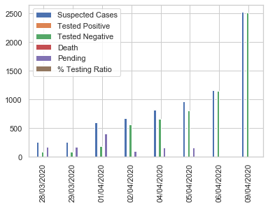

```python
case_bots.plot(kind='bar')
```

A basic graph. Everything eems to be working but now let me get back to graphs that are more meaningful.

```python
suspected_cases =  case_bots[['Suspected Cases', 'Tested Negative', 'Tested Positive']]
suspected_cases.head(8)
```

|  | Suspected Cases | Tested Negative | Tested Positive |
| --- | --- | --- | --- |
| 28/03/2020 | 259 | 90 | 0 |
| 29/03/2020 | 259 | 90 | 3 |
| 01/04/2020 | 593 | 189 | 4 |
| 02/04/2020 | 670 | 562 | 4 |
| 04/04/2020 | 820 | 656 | 4 |
| 05/04/2020 | 966 | 804 | 6 |
| 06/04/2020 | 1154 | 1148 | 6 |
| 09/04/2020 | 2527 | 2514 | 13 |

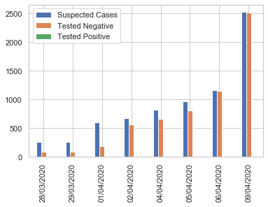

```python
suspected_cases.plot(kind='bar')
```

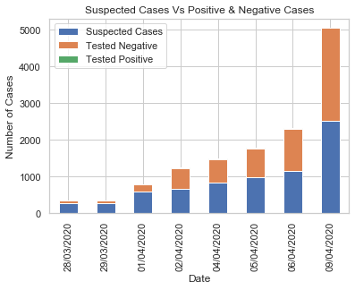

```python
#Stacked bar graph to compare suspected cases vs Posistive vs Negative
sus_plot = suspected_cases.plot(kind='bar',stacked=True,title="Suspected Cases Vs Positive & Negative Cases")
sus_plot.set_xlabel("Date")
sus_plot.set_ylabel("Number of Cases")
```

Figure 2.1.1

Analysis

# Suspected Cases(Tested) Vs Positive & Negative Cases(Results)

The graphs above make it is clear that for tests that are currently done almost 90% return in the negative. This is a clear indication that the disease is still under control in Botswana.

It is also can be derived from the graph that when the testing began on the 28/03/2020 the testing was very slow and the country had a high number of suspected cases that tested for covid-19 who did not know their status. As time went on especially from the 02/04/2020 the testing pace or efficiency greatly increased as can be seen by the almost even number of stacked graphs(that is the Orange (Tested Negative) and Blue (suspected Cases)).

NB: Please note that in relation to those who tested Negative vs Suspected Cases, those who tested positive are only a fraction of the aforementioned Suspected Cases and those who tested Negative as whole and therefore it will not be clear on the above bar graph(appears that those who tested positive are available).

Let me illustrate Positive tests over time in the following bar graph alone for clarity..

```python
suspected_cases_a =  case_bots[['Tested Positive']]
suspected_cases_a.head(8)
```

|  | Tested Positive |
| --- | --- |
| 28/03/2020 | 0 |
| 29/03/2020 | 3 |
| 01/04/2020 | 4 |
| 02/04/2020 | 4 |
| 04/04/2020 | 4 |
| 05/04/2020 | 6 |
| 06/04/2020 | 6 |
| 09/04/2020 | 13 |

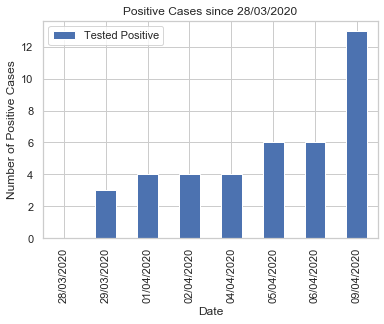

```python
positive_plot = suspected_cases_a.plot(kind='bar',stacked=False,title="Positive Cases since 28/03/2020")
positive_plot.set_xlabel("Date")
positive_plot.set_ylabel("Number of Positive Cases")
```

Analysis

The histograph below clearly too illustrate the above finding.

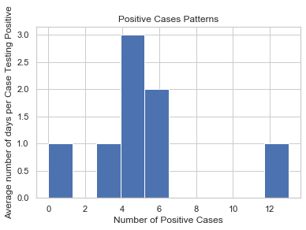

```python
# Histogram help us to look at the positive cases in more detail.
hist_plot = suspected_cases['Tested Positive'].hist()
hist_plot.set_title("Positive Cases Patterns")
hist_plot.set_xlabel("Number of Positive Cases")
hist_plot.set_ylabel("Average number of days per Case Testing Positive")
```

The line graph below clearly illustrate the rate of increase in confirmed positive cases:

Note But before I can plot the line series I need to have the "date" data on above graph in the format of a datetime datatype for the graph to work. The above data as it is now in a string format. For quick analysis I will hardcode the data as follows:

But note with a large set of data this could be tedious , it would better to have the date in datetime format so you can use some of the pandas function to easily do the job.

### COVID-19 Spread Analysis

The spread Analysis will be two sections as below

1. The spread across Botswana
2. The spread trends in the world

##### Botswana Spread Analysis

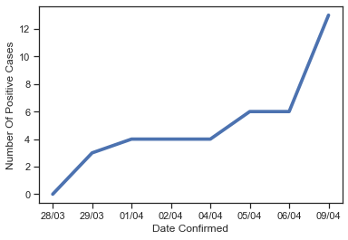

```python
#plotting a line graph

plt.plot(['28/03', '29/03', '01/04', '02/04', '04/04', '05/04', '06/04', '09/04'],[0,3,4,4,4,6,6,13])
plt.ylabel('Number Of Positive Cases')
plt.xlabel('Date Confirmed')
plt.show()
```

The above graph clearly indicates the rate at which confirmed cases are revealed in Botswana. As seen the graph is steadily moving up and starkly jumped upward on the 09/04/2020. This is a worrying trend.

##### Pie Chart Analysis: comparing Total suspected cases vs Positive Cases vs Negative Cases

Below I plot Total Suspected Cases against Positive Cases vs Negative Cases to show the severity of the pandemic in Botswana. This data will be plotted on the last date cases.

```python
#loading last confirmed data
pie_tb = cases['09/04/2020']
pie_tb.head()
```

```
0    2527
1      13
2    2514
3       0
4       1
Name: 09/04/2020, dtype: int64
```

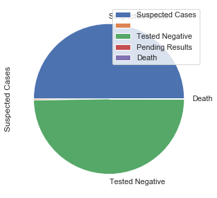

```python
pie_total_cases = pd.DataFrame({'Suspected Cases': [2527, 13, 2514 , 0, 1]},
                  index=['Suspected Cases', '', 'Tested Negative', 'Pending Results', 'Death'])
plot = pie_total_cases.plot.pie(y='Suspected Cases', figsize=(5, 5))
```

The pie chart simply illustrate what has already been alluded before; that it seems for people that are tested for the disease most of them, their results come out negative. This is a good thing for Botswana. It would be great then if now all the 13 cases recorded could recover. As it is, no data has been recorded of any recovery in Botswana yet.

Now going over the graphs and analysis it may seem that the testing and rate of results coming out seems to be adequate. But for us to have a better appreciation of this we should look at the some variables that better determines whether

- the testing being done is sufficient ?
- and satisfactory?

To determine the above I will look at the

- Testing Centres in Botswana
- Total Tested(Suspected Cases) in relation to the population
- % Testing Ratio

##### Total tested people in relation to country population

I will compare the tested numbers in relation to population size of Botswana as percentage to see if the numbers being tested are really satisfactory as figure 2.1.1 seems to suggest.

```python
# Adding the testing capcity as percentage to the data frame

testing_capacity = pd.DataFrame( {"Suspected(Total Tested)" : [259,259,593,670,820,966,1154,2527],
                           "% Testing Ratio" : [0.01,0.01,0.02,0.03,0.03,0.04,0.05,0.11]},
                           index=['28/03/2020', '29/03/2020', '01/04/2020', '02/04/2020', '04/04/2020', '05/04/2020', '06/04/2020', '09/04/2020'])
testing_capacity.head(8)
```

|  | Suspected(Total Tested) | % Testing Ratio |
| --- | --- | --- |
| 28/03/2020 | 259 | 0.01 |
| 29/03/2020 | 259 | 0.01 |
| 01/04/2020 | 593 | 0.02 |
| 02/04/2020 | 670 | 0.03 |
| 04/04/2020 | 820 | 0.03 |
| 05/04/2020 | 966 | 0.04 |
| 06/04/2020 | 1154 | 0.05 |
| 09/04/2020 | 2527 | 0.11 |

figure 2.1.2

So far the tested numbers expressed as a percentage from the table (figure 2.1.2) above clearly are not satisfactory. The table clearly shows that as of the last updated data on the 09/04/2020 only about 0.11% of the population was tested. The data viewed from this perspective becomes a cause for concern.

This could also be interpreted that given the little data we have we do not yet have a proper appreciation of extent of the pandemic in Botswana.

To put everything in perspective we have to appreciate that as of 09/04/2020 Botswana only had two testing centres with a testing capacity of 900people per day.

```python
# Testing Capacity Botswana
testing_Centres = 2
a = 2351627
b = '900/people per day'

# Displaying the Capacity

display(HTML("<h1 style='padding:5px; font-size: 25px;'>BOTSWANA'S TESTING CAPACITY</h1>"
             "<div style = 'background-color:Transparent; padding: 30px '>" +
             "<span style='background-color:#023246; padding:20px; color: #ffff; font-size:20px;margin-left:0px float:left; border: 1px solid #e0e0e0;box-shadow: 0 3px 6px 1px rgba(0, 0, 0, 0.16); '> TESTING FACILITIES "  + str(testing_Centres) +"</span>" +
             "<span style='background-color:#D4D4CE; padding:20px; color: #ffff; font-size:20px;margin-left:5px; border: 1px solid #e0e0e0;box-shadow: 0 3px 6px 1px rgba(0, 0, 0, 0.16);'> CAPACITY " + str(b) + "</span>"+
              "<span style='background-color:PURPLE; padding:20px; color: #ffff; font-size:20px;margin-left:5px; border: 1px solid #e0e0e0;box-shadow: 0 3px 6px 1px rgba(0, 0, 0, 0.16);'> POPULATION " + str(a) + "</span>"+
             "</div>")
       )
```

BOTSWANA'S TESTING CAPACITY

TESTING FACILITIES 2 CAPACITY 900/people per day POPULATION 2351627

This means that Botswana have a 0.03% capacity to test for covid-19 per day. Let take a closer look at the following graph to test if it currently such capacity.

##### Quick analysis

Pandas has a quick tool in the form of a command known as describe(). If we run it as follows; we will get quick analysis of table (figure 2.1. ) above in the notebook.

```python
testing_capacity.describe()
```

|  | Suspected(Total Tested) | % Testing Ratio |
| --- | --- | --- |
| count | 8.000000 | 8.000000 |
| mean | 906.000000 | 0.037500 |
| std | 726.146778 | 0.032404 |
| min | 259.000000 | 0.010000 |
| 25% | 509.500000 | 0.017500 |
| 50% | 745.000000 | 0.030000 |
| 75% | 1013.000000 | 0.042500 |
| max | 2527.000000 | 0.110000 |

```python
testing_capacity['% Testing Ratio'].describe()
```

```
count    8.000000
mean     0.037500
std      0.032404
min      0.010000
25%      0.017500
50%      0.030000
75%      0.042500
max      0.110000
Name: % Testing Ratio, dtype: float64
```

- Testing in Botswana though relatively low in relation to the population, it is satisfactory given the resources at our  
  disposal
- Testing was ramped since first dates of data reporting and as of date now slightly above what the country resources can  
  achieve per day

All of this is captured and illustrated in the table figure (2.1.3) and bar graph figure (2.1.4) below

```python
testing_capacity_Ave = pd.DataFrame( {"Date" : [da_28 ,da_29,da_1,da_2,da_4,da_5,da_6,da_9],
                           "% Testing Ratio" : [0.01,0.01,0.02,0.03,0.03,0.04,0.05,0.11],
                           "% Testing Ratio Average" : [0.037,0.037,0.037,0.037,0.037,0.037,0.037,0.037]        },
                           )
testing_capacity_Ave
```

|  | Date | % Testing Ratio | % Testing Ratio Average |
| --- | --- | --- | --- |
| 0 | Mar 28 2020, 00:00:00 | 0.01 | 0.037 |
| 1 | Mar 29 2020, 00:00:00 | 0.01 | 0.037 |
| 2 | Apr 01 2020, 00:00:00 | 0.02 | 0.037 |
| 3 | Apr 02 2020, 00:00:00 | 0.03 | 0.037 |
| 4 | Apr 04 2020, 00:00:00 | 0.03 | 0.037 |
| 5 | Apr 05 2020, 00:00:00 | 0.04 | 0.037 |
| 6 | Apr 06 2020, 00:00:00 | 0.05 | 0.037 |
| 7 | Apr 09 2020, 00:00:00 | 0.11 | 0.037 |

figure 2.1.3

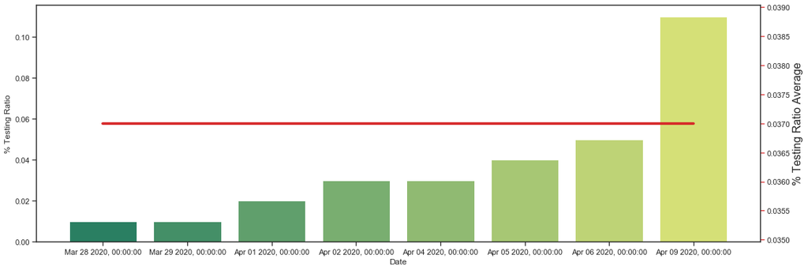

```python
fig, ax1 = plt.subplots(figsize=(18.7,6.27))
color = 'tab:red'

ax2 = sns.set(style="ticks", rc={"lines.linewidth": 3.7})
ax1 = sns.barplot(x='Date', y='% Testing Ratio', data = testing_capacity_Ave, palette='summer')
ax1.tick_params(axis='y')
ax2 = ax1.twinx()
ax2.set_ylabel('% Testing Ratio Average', fontsize=16)
ax2 = sns.lineplot(x='Date', y='% Testing Ratio Average', data = testing_capacity_Ave, sort=False, color=color)
ax2.tick_params(axis='y', color=color)
#show plot
plt.show()
```

figure 2.1.4

##### Summary analysis capacity

Testing is going as per our capacity given the current facilities.m In short so far the following people in Botswana have been tested:

```python
per = 2527/2351627
'{0:.3f}'.format(per)

# Displaying total people tested as a percentage

display(HTML("<h1 style='padding:5px; font-size: 25px;'>Total People Tested %</h1>"
             "<div style = 'background-color:Transparent; padding: 50px '>" +
              "<span style='background-color:PURPLE; width:100%; padding:25px 150px 25px 150px; color: #ffff; font-size:20px;margin-left:280px; border: 1px solid #e0e0e0;box-shadow: 0 3px 6px 1px rgba(0, 0, 0, 0.16);'>" + str('{0:.3f}'.format(per)) + " % </span>"+
             "</div>")
       )
```

So it is clear we as of now are not really clear with the real picture of the pandemic in the country. We are basically banking on the figures coming out negative after tests as well as not many people getting sick locally.

So it follows logically that this to some extent might be true, most people are not sick or the disease has not yet taken foot in the country.

Mapping Covid-19 in Botswana

With this in mind it would make sense in looking at confirmed cases. Where in the country are they; so as to allow for proper decisions to be made. for resistance where it appears to be prevalent the government might cordon off the areas from areas still clear.

### Geographic Presentation of Covid-19

The map of the whole world will show graphically which places in country are affected the most or have confirmed cases. It will gives us a broader picture say which places need to be coordoned off from others as per cases found in the different areas.